# Programming in R Coursework

wa23772

2023-12-04

# Data Loading, Cleaning & Exploration

### Loading the Data

```r
#load in the required packages
library(tidyverse) #tidyverse imported for ggplot and pipes
library(ggplot2) #for plotting
library(vroom) #for loading in the data
library(rstatix) #statistical analysis
library(Hmisc) #data analysis
library(ggpubr) #used for ggplot
library(fitdistrplus) #for checking distriution of residuals
library(DHARMa) #for checking of general linear mixed models (GLMMs)
```

```r
NAO_data <- vroom("NAO_wa23772.tsv") #load in the NAO data
mass_data <- vroom("mass_wa23772.tsv") #load in the data on weight, population, ect.
```

```r
summary(NAO_data) #summarise the data, check for outliers
```

```
##       year         month                NAO
##  Min.   :1980   Length:492         Min.   :-2.1863
##  1st Qu.:1990   Class :character   1st Qu.: 0.9003
##  Median :2000   Mode  :character   Median : 0.9955
##  Mean   :2000                      Mean   : 0.8761
##  3rd Qu.:2010                      3rd Qu.: 1.0937
##  Max.   :2020                      Max.   : 3.3152
```

```r
view(NAO_data)
summary(mass_data) #summarise the data and observe the data structure, identify predictor variables alongside NAO. Errors include NAs in weight and numerical values in sex.
```

```
##        ID             age             sex               n_babies
##  Min.   :  1.0   Min.   : 0.000   Length:3114        Min.   :0.000
##  1st Qu.:106.2   1st Qu.: 2.000   Class :character   1st Qu.:0.000
##  Median :200.0   Median : 4.000   Mode  :character   Median :1.000
##  Mean   :202.6   Mean   : 4.722                      Mean   :1.011
##  3rd Qu.:302.0   3rd Qu.: 7.000                      3rd Qu.:2.000
##  Max.   :398.0   Max.   :16.000                      Max.   :2.000
##
##       site            year         pop_size         weight
##  Min.   :1.000   Min.   :1980   Min.   :125.0   Min.   : 2.930
##  1st Qu.:1.000   1st Qu.:1993   1st Qu.:143.0   1st Qu.: 5.990
##  Median :2.000   Median :2002   Median :148.0   Median : 7.050
##  Mean   :2.039   Mean   :2002   Mean   :147.8   Mean   : 7.271
##  3rd Qu.:3.000   3rd Qu.:2012   3rd Qu.:152.0   3rd Qu.: 8.410
##  Max.   :3.000   Max.   :2020   Max.   :169.0   Max.   :12.940
##                                                 NA's   :294
```

```r
view(mass_data)
```

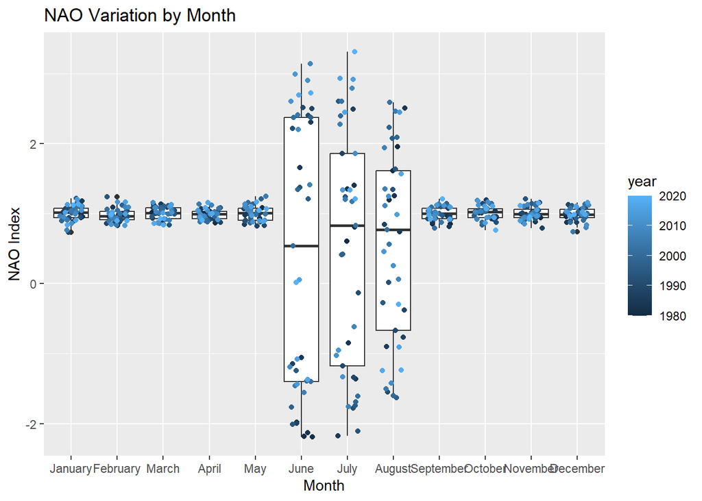

```r
NAO_data$month <- factor(NAO_data$month, levels = c("January", "February", "March", "April", "May", "June", "July", "August", "September", "October", "November", "December")) #making months a factor to order the plot correctly

#ggplot to spot variation in NAO by month
ggplot(data = NAO_data, aes(x = month, y = NAO)) +
  geom_boxplot() +
  geom_jitter(width = 0.25, aes(colour = year)) +
  labs(title = "NAO Variation by Month", x = "Month", y = "NAO Index")
```

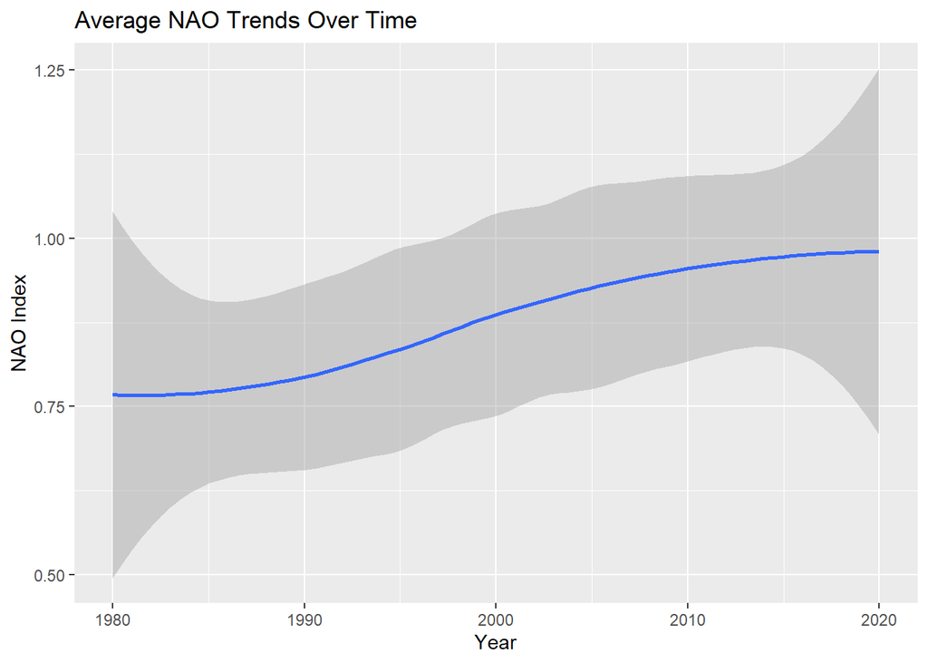

```r
#ggplot to check for trends in NAO by year, used geom smooth to highlight non linear data
ggplot(data = NAO_data, aes(x = year, y = NAO)) + geom_smooth() +
  labs(title = "Average NAO Trends Over Time", x = "Year", y = "NAO Index")
```

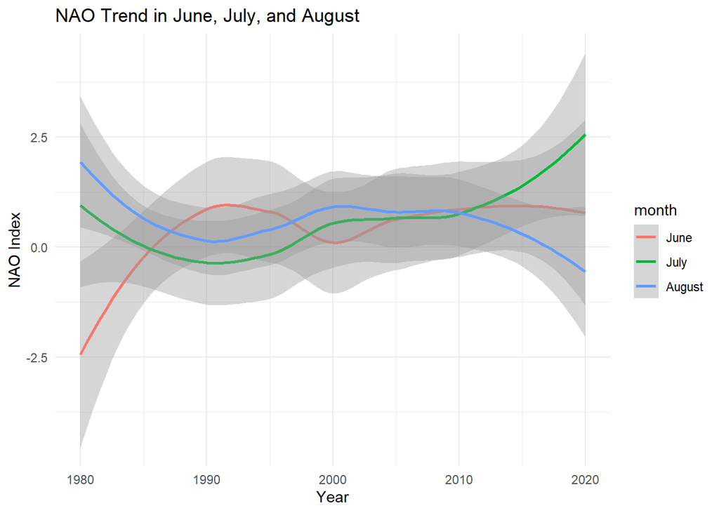

```r
# Filter data for June, July, and August
summer_data <- subset(NAO_data, month %in% c("June", "July", "August"))

# Plot NAO trend over the years for each month, checking for months which show significant differences to the others
ggplot(data = summer_data, aes(x = year, y = NAO, color = month)) +
  geom_smooth() +
  labs(title = "NAO Trend in June, July, and August",
       x = "Year",
       y = "NAO Index") +
  theme_minimal()
```

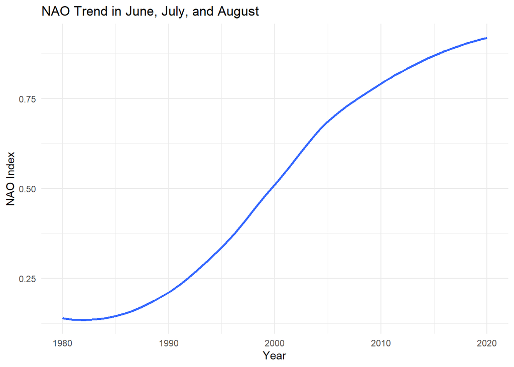

```r
ggplot(data = summer_data, aes(x = year, y = NAO)) +
  geom_smooth(method = "loess", se = FALSE) +
  labs(title = "NAO Trend in June, July, and August",
       x = "Year",
       y = "NAO Index") +
  theme_minimal() #ggplot to view the overall increase in mean summertime NAO over the years
```

```r
Summer_NAO <- NAO_data[NAO_data$month %in% c("June", "July", "August"), ] #isolating the summer months for further analysis

view(Summer_NAO) #viewing the summer data

yearly_breakdown <- Summer_NAO %>%
  group_by(year) %>%
  summarise(mean_yearly_summer_NAO=mean(NAO)) #take the average NAO by year to analyse the effect of NAO by weight, taking the average NAO of each year.
```

### Cleaning the Data

```r
#plot of weight over time indicated incorrect values in sex, use the operators to convert numerical values into NAs.
mass_data$sex[mass_data$sex %in% c("0", "1", "2")] <- "NA"
mass_data$sex[mass_data$sex %in% c("na", "NA")] <- NA #incorrectly assigned NA as "NA", correcting to a factor.
na_removed_data <- mass_data %>%
  drop_na(sex) #dropping NA values from the dataset as sex appears to be a influential factor.

#The two datasets were merged to run analysis on the effects of NAO.
merged_data <- merge(yearly_breakdown, na_removed_data, by = "year")
view(merged_data) #the data has merged successfully and the mean summer NAO is provided for every year.

merged_data <- merged_data %>%
  drop_na(mean_yearly_summer_NAO) %>%
  drop_na(weight) # dropping the NAs from weight and NAO. This avoids data skew
```

The dataset was merged by year. The NAs and numbers in sex were removed, NAs in weight and NAO were also removed to avoid data skew.

### Data Exploration

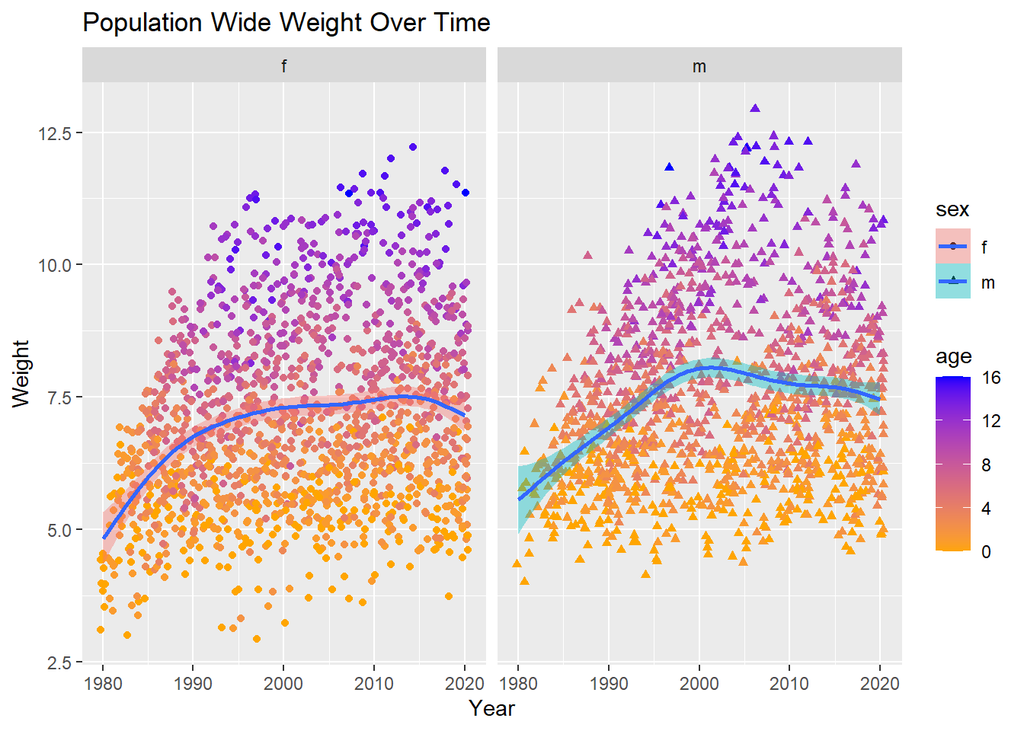

```r
ggplot(data = merged_data, aes(x=year, y=weight, fill=sex)) + #Plot to review weight change over time by sex
  geom_jitter(aes(colour = age, shape = sex)) + #jitter plot used alongside smooth to check for obvious outliers
  facet_wrap(~sex) +
  geom_smooth() +
  scale_colour_gradient(low = "orange", high = "blue") +
  labs(title = "Population Wide Weight Over Time", x = "Year", y = "Weight") #using an orange to blue colour pallette for colour blindness accessibility.
```

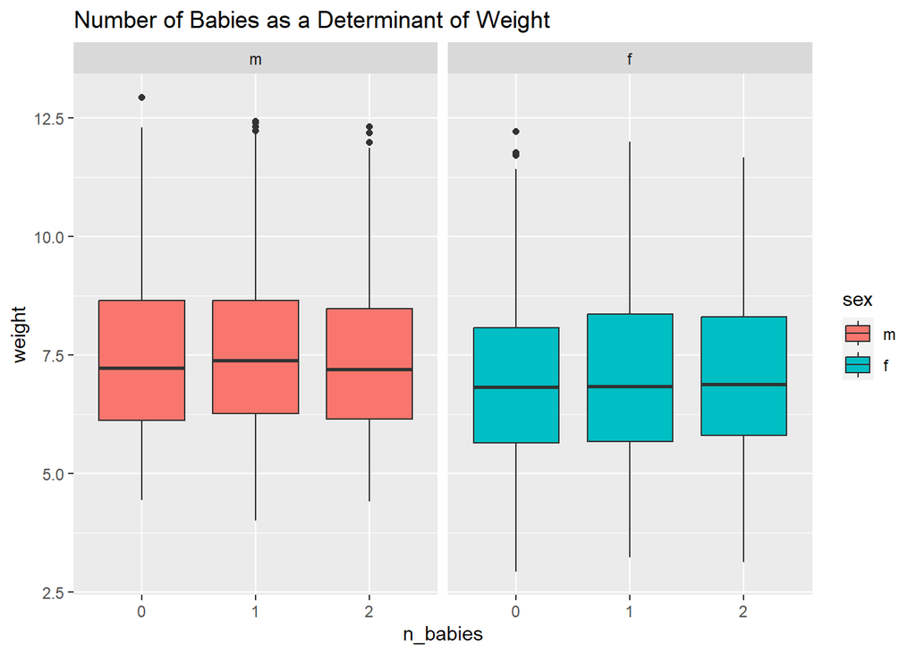

```r
babies_made_factoral_data <- merged_data
babies_made_factoral_data$sex <- factor(babies_made_factoral_data$sex, levels=c("m", "f")) #made n_babies a factor for ease of plotting from a seperate data frame
babies_made_factoral_data$n_babies <- factor(babies_made_factoral_data$n_babies, levels=c(0, 1, 2)) #making n_babies a tiered factoral

#adding a boxplot to see if n_babies has a significant impact on mean sheep weight
ggplot(data = babies_made_factoral_data, aes(x = n_babies, y = weight, fill = sex)) + geom_boxplot() + facet_wrap(~sex) + labs(title="Number of Babies as a Determinant of Weight")
```

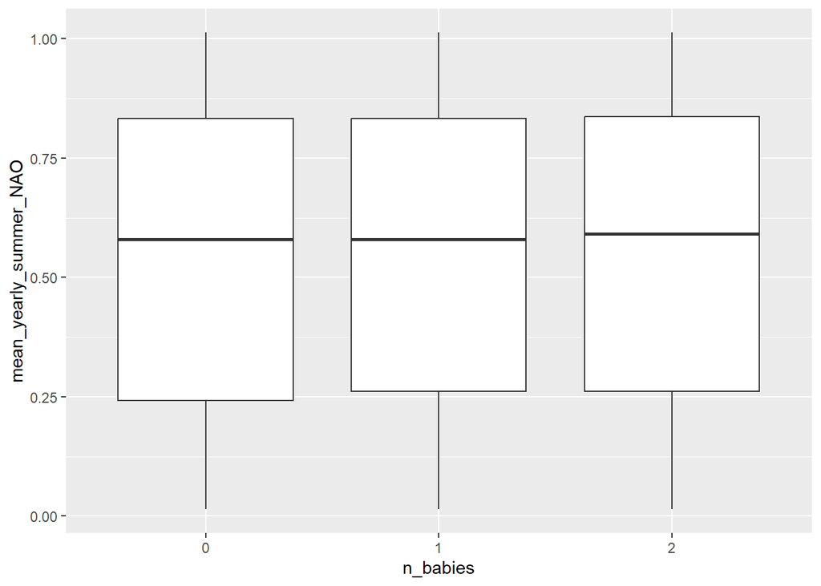

```r
ggplot(data = babies_made_factoral_data, aes(x = n_babies, y = mean_yearly_summer_NAO)) +
  geom_boxplot() #plot showing difference in number of offspring due to NAO variance
```

Differences in weight increase by sex were evident. No significant deviation in weight was detected due to an increase in offspring number.

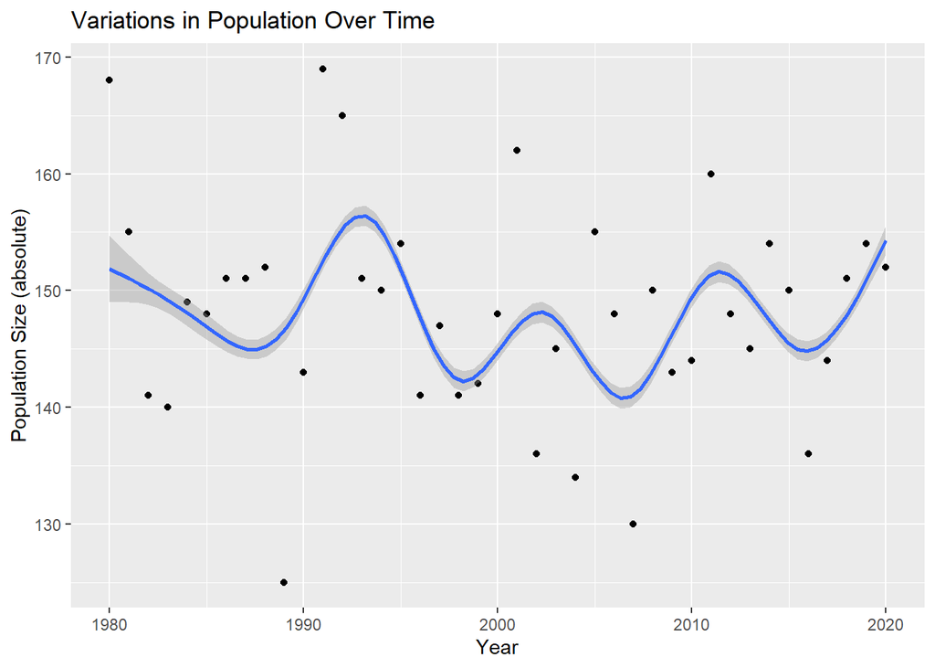

```r
ggplot(data = na_removed_data, aes(x = year, y = pop_size)) + geom_point() +
  geom_smooth() +
  labs(title = "Variations in Population Over Time", x = "Year", y = "Population Size (absolute)") #ggplot of population trends over time
```

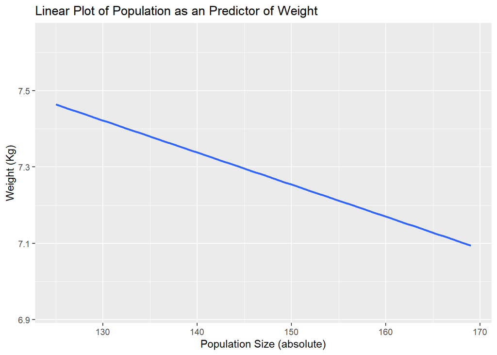

```r
ggplot(data = na_removed_data, aes(x=pop_size, y = weight, colour = age)) +
  geom_smooth(method = "lm", fill = NA) +
  labs(title = "Linear Plot of Population as an Predictor of Weight", x = "Population Size (absolute)", y = "Weight (Kg)") #Linear effects of population as a predictor of weight
```

Variation on population appears to have a near significant impact on weight, and should be considered as a random effect at the very least.

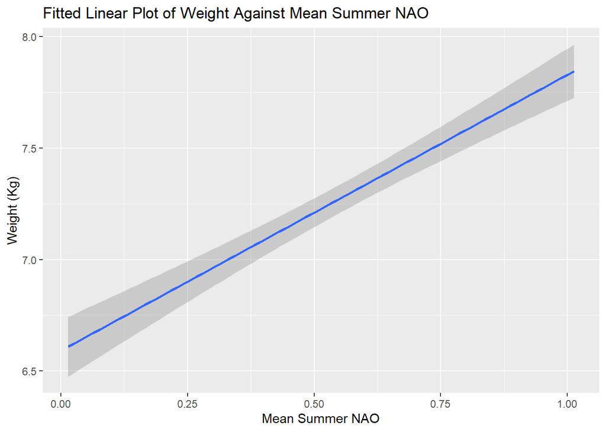

```r
ggplot(data = merged_data, aes(x = mean_yearly_summer_NAO, y = weight)) +
  geom_smooth(method = "lm") +
  labs(title = "Fitted Linear Plot of Weight Against Mean Summer NAO", x = "Mean Summer NAO", y = "Weight (Kg)") #viewing the linear trend of the data of weight against NAO
```

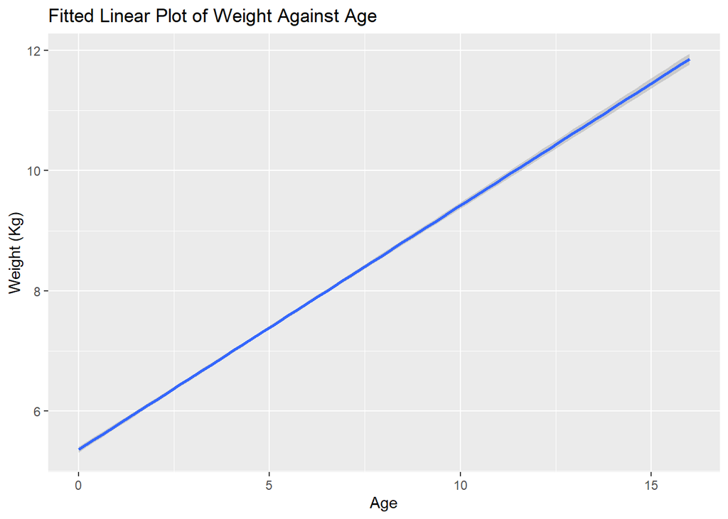

```r
ggplot(data = merged_data, aes(x = age, y = weight)) +
  geom_smooth(method = "lm") +
  labs(title = "Fitted Linear Plot of Weight Against Age", x = "Age", y = "Weight (Kg)") #viewing the linear trend of the data age vs weight
```

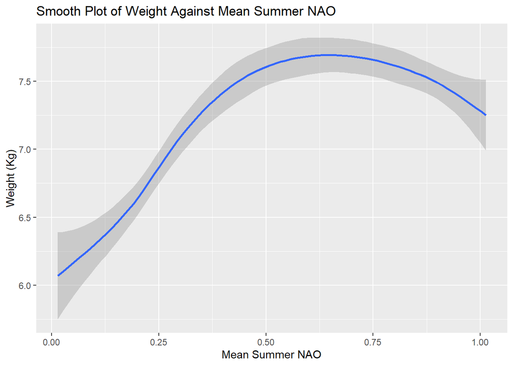

```r
ggplot(data = merged_data, aes(x = mean_yearly_summer_NAO, y = weight)) + geom_smooth() + labs(title = "Smooth Plot of Weight Against Mean Summer NAO", x = "Mean Summer NAO", y = "Weight (Kg)") #checking the smooth version to see deviation from the linear relationship
```

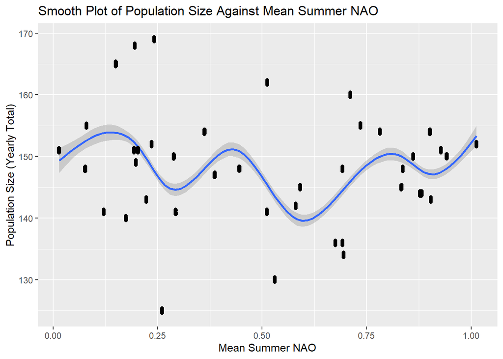

```r
ggplot(data = merged_data, aes(x = mean_yearly_summer_NAO, y = pop_size)) +
  geom_smooth() +
  geom_jitter() +
  labs(title = "Smooth Plot of Population Size Against Mean Summer NAO", x = "Mean Summer NAO", y = "Population Size (Yearly Total)")# checking for NAO influence on pop_size - pop size has a minor influence on sheep weight
```

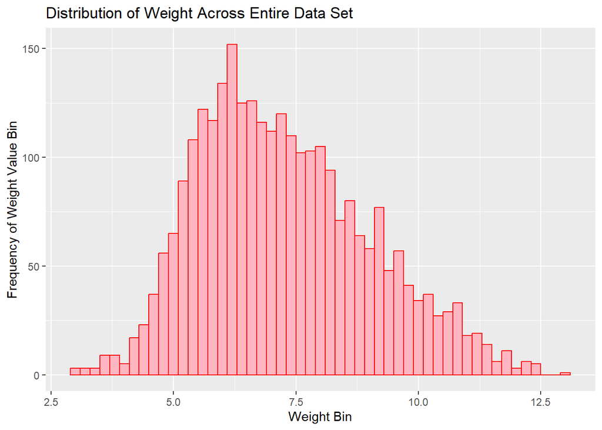

```r
ggplot(data = merged_data, aes(x = weight)) +
  geom_histogram(binwidth = 0.2, colour = "red", fill = "lightpink") +
  labs(title = "Distribution of Weight Across Entire Data Set", x = "Weight Bin", y = "Frequency of Weight Value Bin") #weight distribution across the total population
```

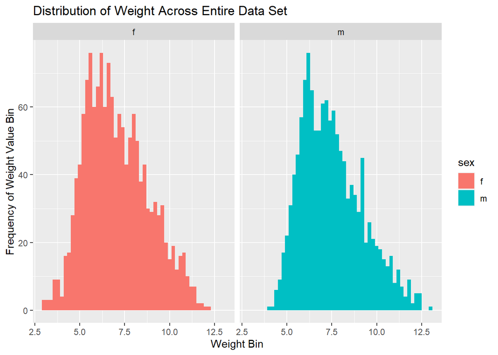

```r
ggplot(data = merged_data, aes(x = weight, fill = sex)) +
  geom_histogram(binwidth = 0.2) +
  labs(title = "Distribution of Weight Across Entire Data Set", x = "Weight Bin", y = "Frequency of Weight Value Bin") + facet_wrap(~sex) #weight ditribution faceted by sex.
```

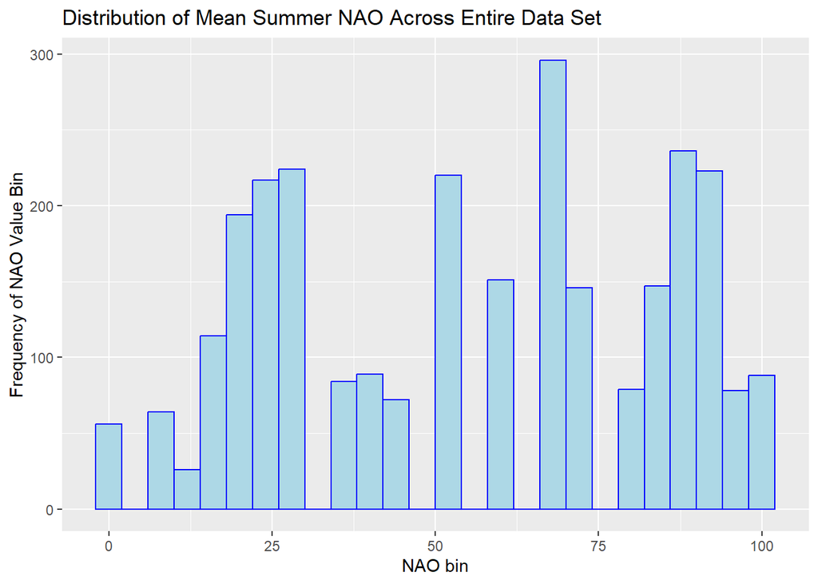

```r
ggplot(data = merged_data, aes(x = mean_yearly_summer_NAO*100)) +
  geom_histogram(binwidth = 4, colour = "blue", fill = "lightblue") +
  labs(title = "Distribution of Mean Summer NAO Across Entire Data Set", x = "NAO bin", y = "Frequency of NAO Value Bin") #checking for normal distribution of data in NAO, * 100 for ease of viewing.
```

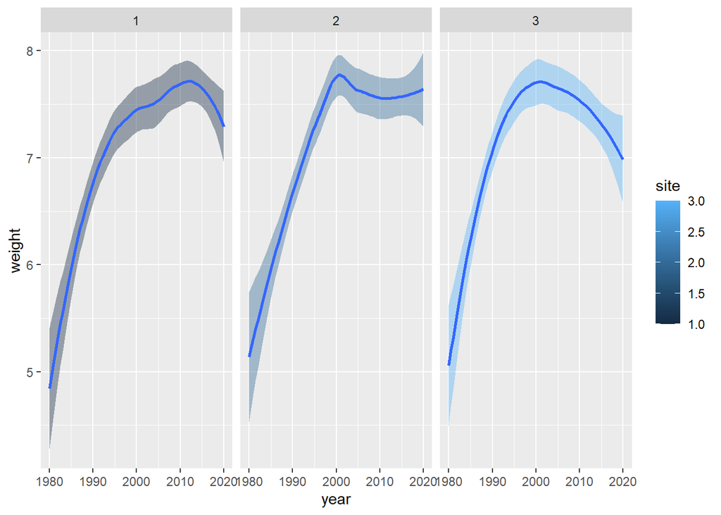

```r
ggplot(data = merged_data, aes(x=year, y=weight, fill=site)) +
  geom_smooth() +
  facet_wrap(~site) #ggplot highlighting differences between sites, when looking at variation in mean weight over time
```

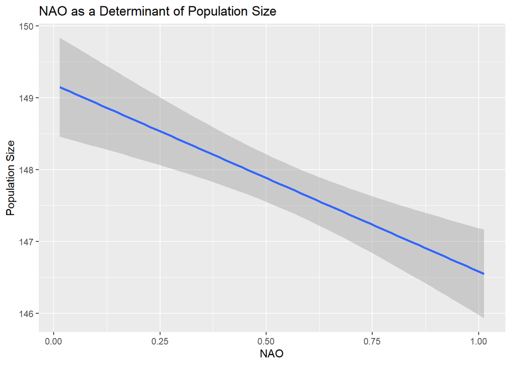

```r
ggplot(data = merged_data, aes(x = mean_yearly_summer_NAO, y = pop_size)) +
  geom_smooth(method = "lm") +
  labs(title = "NAO as a Determinant of Population Size", x = "NAO", y = "Population Size")#plot investigating the "linear" relationship between NAO and population.
```

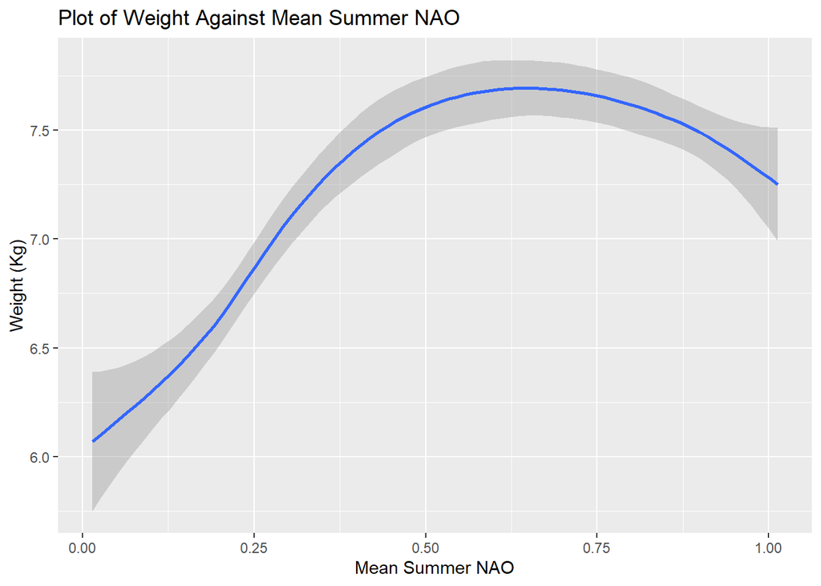

```r
ggplot(data = merged_data, aes(x = mean_yearly_summer_NAO, y = weight, colour = ID)) + geom_smooth() + labs(title = "Plot of Weight Against Mean Summer NAO", x = "Mean Summer NAO", y = "Weight (Kg)") #checking the smooth version to see deviation from the linear relationship
```

We can observe that NAO, age and sex had an impact on weight. Other variables are likely influential. Population size, site and NAOs effect on pop size were deemed likely to have an impact on weight.

```r
?fitdist()
```

```
## starting httpd help server ... done
```

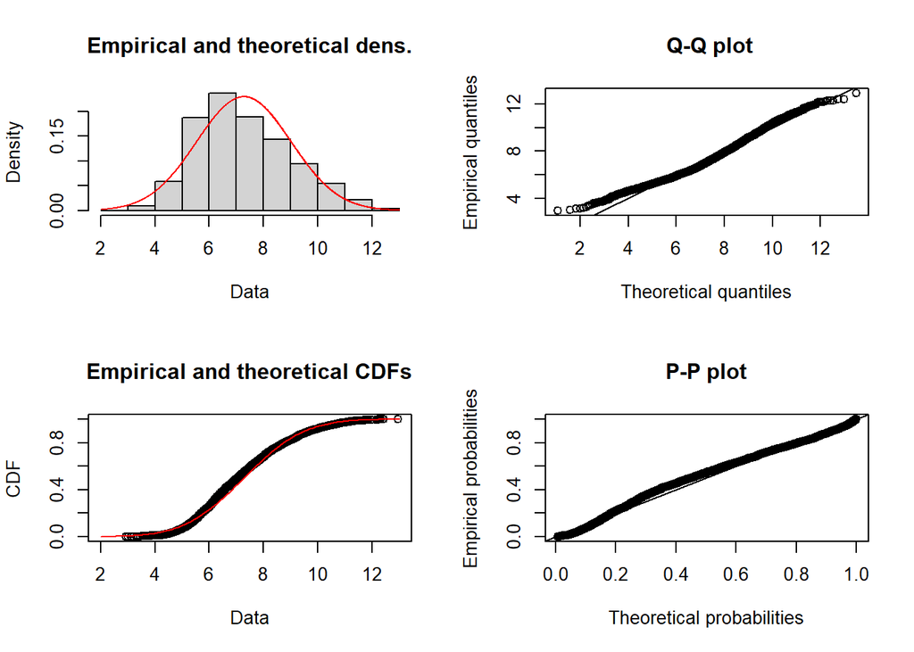

```r
library(fitdistrplus)

fit <- fitdist(merged_data$weight, "norm") #checking residuals and
plot(fit)
```

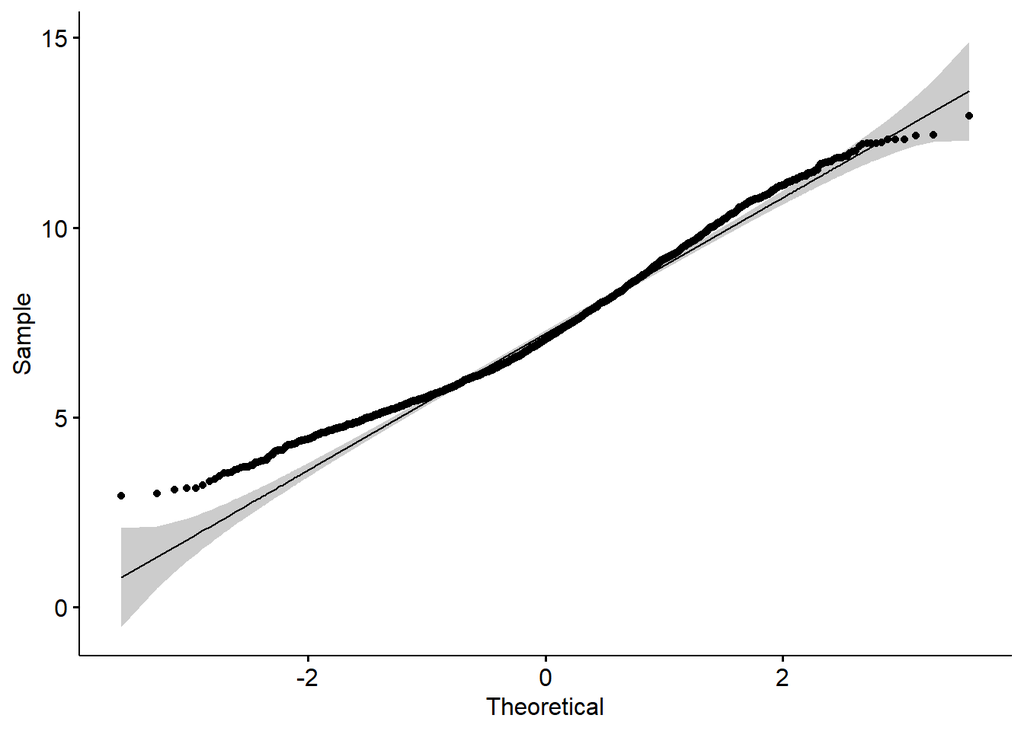

```r
ggqqplot(data = merged_data, x = "weight")
```

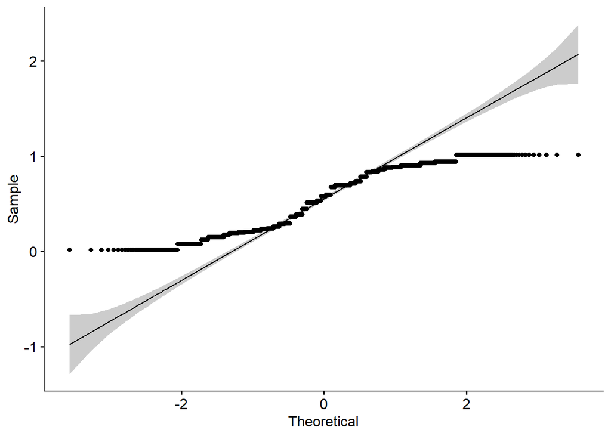

```r
ggqqplot(data = merged_data, x = "mean_yearly_summer_NAO")
```

```r
library(e1071)
class(merged_data$mean_yearly_summer_NAO) #checking the data class
```

```
## [1] "numeric"
```

```r
length(merged_data$mean_yearly_summer_NAO) #checking the number of data points
```

```
## [1] 2804
```

```r
any(is.na(merged_data$mean_yearly_summer_NAO)) #checking for NA values
```

```
## [1] FALSE
```

```r
NAO_skewness <- skewness(merged_data$mean_yearly_summer_NAO) #checking for skew in the data
NAO_skewness
```

```
## [1] -0.1135583
```

A skew of the NAO QQ-plot appears, however testing using the skew function from the e1071 library indicated the residual distribution to be roughly symmetrical.

# Determining Significant Factors

```r
cor.test(merged_data$mean_yearly_summer_NAO, merged_data$weight, method = "spearman") #
```

```
##
##  Spearman's rank correlation rho
##
## data:  merged_data$mean_yearly_summer_NAO and merged_data$weight
## S = 2976193429, p-value < 2.2e-16
## alternative hypothesis: true rho is not equal to 0
## sample estimates:
##       rho
## 0.1900123
```

```r
lm_pop_size <- lm(pop_size ~ mean_yearly_summer_NAO, data = merged_data) #model to assess NAO impact on pop size
lm_weight_NAO <- lm(weight ~ mean_yearly_summer_NAO, data = merged_data) #model to assess NAO impact on weight - verifying the earlier spearman's rank via anova
lm_weight_popsize <- lm(weight ~ pop_size, data = merged_data) #model assessing impact of pop_size on weight

lm_weight_sex <- lm(weight ~ sex, data = merged_data) #model assessing impact of sex on weight

lm_weight_site <- lm(weight ~ site, data = merged_data) #assessing impact of site on weight

lm_all <- lm(weight ~ mean_yearly_summer_NAO + sex + age + pop_size, data = merged_data) #assessing all effecting variables in a model

lm_all_interaction <- lm(weight ~ mean_yearly_summer_NAO + sex + age + pop_size + year:mean_yearly_summer_NAO, data = merged_data) #assessing all effecting variables in a model

anova(lm_pop_size)
```

```
## Analysis of Variance Table
##
## Response: pop_size
##                          Df Sum Sq Mean Sq F value    Pr(>F)
## mean_yearly_summer_NAO    1   1572 1571.83  20.286 6.942e-06 ***
## Residuals              2802 217109   77.48
## ---
## Signif. codes:  0 '***' 0.001 '**' 0.01 '*' 0.05 '.' 0.1 ' ' 1
```

```r
anova(lm_weight_NAO)
```

```
## Analysis of Variance Table
##
## Response: weight
##                          Df Sum Sq Mean Sq F value    Pr(>F)
## mean_yearly_summer_NAO    1  355.5  355.52  122.38 < 2.2e-16 ***
## Residuals              2802 8139.8    2.90
## ---
## Signif. codes:  0 '***' 0.001 '**' 0.01 '*' 0.05 '.' 0.1 ' ' 1
```

```r
anova(lm_weight_popsize)
```

```
## Analysis of Variance Table
##
## Response: weight
##             Df Sum Sq Mean Sq F value  Pr(>F)
## pop_size     1   15.5 15.4656  5.1103 0.02386 *
## Residuals 2802 8479.8  3.0263
## ---
## Signif. codes:  0 '***' 0.001 '**' 0.01 '*' 0.05 '.' 0.1 ' ' 1
```

```r
anova(lm_weight_sex)
```

```
## Analysis of Variance Table
##
## Response: weight
##             Df Sum Sq Mean Sq F value    Pr(>F)
## sex          1  130.1 130.134   43.59 4.826e-11 ***
## Residuals 2802 8365.1   2.985
## ---
## Signif. codes:  0 '***' 0.001 '**' 0.01 '*' 0.05 '.' 0.1 ' ' 1
```

```r
anova(lm_weight_site)
```

```
## Analysis of Variance Table
##
## Response: weight
##             Df Sum Sq Mean Sq F value Pr(>F)
## site         1    0.0 0.01481  0.0049 0.9443
## Residuals 2802 8495.3 3.03185
```

```r
anova(lm_all)
```

```
## Analysis of Variance Table
##
## Response: weight
##                          Df Sum Sq Mean Sq    F value Pr(>F)
## mean_yearly_summer_NAO    1  355.5   355.5   647.8534 <2e-16 ***
## sex                       1  128.5   128.5   234.1811 <2e-16 ***
## age                       1 6474.1  6474.1 11797.6426 <2e-16 ***
## pop_size                  1    1.1     1.1     2.0858 0.1488
## Residuals              2799 1536.0     0.5
## ---
## Signif. codes:  0 '***' 0.001 '**' 0.01 '*' 0.05 '.' 0.1 ' ' 1
```

```r
anova(lm_all_interaction)
```

```
## Analysis of Variance Table
##
## Response: weight
##                               Df Sum Sq Mean Sq    F value Pr(>F)
## mean_yearly_summer_NAO         1  355.5   355.5   647.9079 <2e-16 ***
## sex                            1  128.5   128.5   234.2007 <2e-16 ***
## age                            1 6474.1  6474.1 11798.6346 <2e-16 ***
## pop_size                       1    1.1     1.1     2.0859 0.1488
## mean_yearly_summer_NAO:year    1    0.7     0.7     1.2354 0.2665
## Residuals                   2798 1535.3     0.5
## ---
## Signif. codes:  0 '***' 0.001 '**' 0.01 '*' 0.05 '.' 0.1 ' ' 1
```

# Fitting/Testing the GLM

```r
library(broom)
?glm()
glm_model <- glm(weight ~ age + mean_yearly_summer_NAO + sex, data = merged_data, family = gaussian) #setting a glm model to see if mixedeffects and interactions are necessary for a functional model
summary(glm_model)
```

```
##
## Call:
## glm(formula = weight ~ age + mean_yearly_summer_NAO + sex, family = gaussian,
##     data = merged_data)
##
## Coefficients:
##                        Estimate Std. Error t value Pr(>|t|)
## (Intercept)            4.844954   0.035832  135.21   <2e-16 ***
## age                    0.403438   0.003715  108.60   <2e-16 ***
## mean_yearly_summer_NAO 0.502104   0.049083   10.23   <2e-16 ***
## sexm                   0.538639   0.028070   19.19   <2e-16 ***
## ---
## Signif. codes:  0 '***' 0.001 '**' 0.01 '*' 0.05 '.' 0.1 ' ' 1
##
## (Dispersion parameter for gaussian family taken to be 0.5489759)
##
##     Null deviance: 8495.3  on 2803  degrees of freedom
## Residual deviance: 1537.1  on 2800  degrees of freedom
## AIC: 6281.8
##
## Number of Fisher Scoring iterations: 2
```

```r
tidy(glm_model) #using the tidy method to coroborate summary findings
```

```
## # A tibble: 4 × 5
##   term                   estimate std.error statistic  p.value
##   <chr>                     <dbl>     <dbl>     <dbl>    <dbl>
## 1 (Intercept)               4.84    0.0358      135.  0
## 2 age                       0.403   0.00372     109.  0
## 3 mean_yearly_summer_NAO    0.502   0.0491       10.2 3.86e-24
## 4 sexm                      0.539   0.0281       19.2 3.34e-77
```

The glm indicates the significance of the three predictors, high AIC and residual deviance indicate significant variation in weight is unaccounted for.

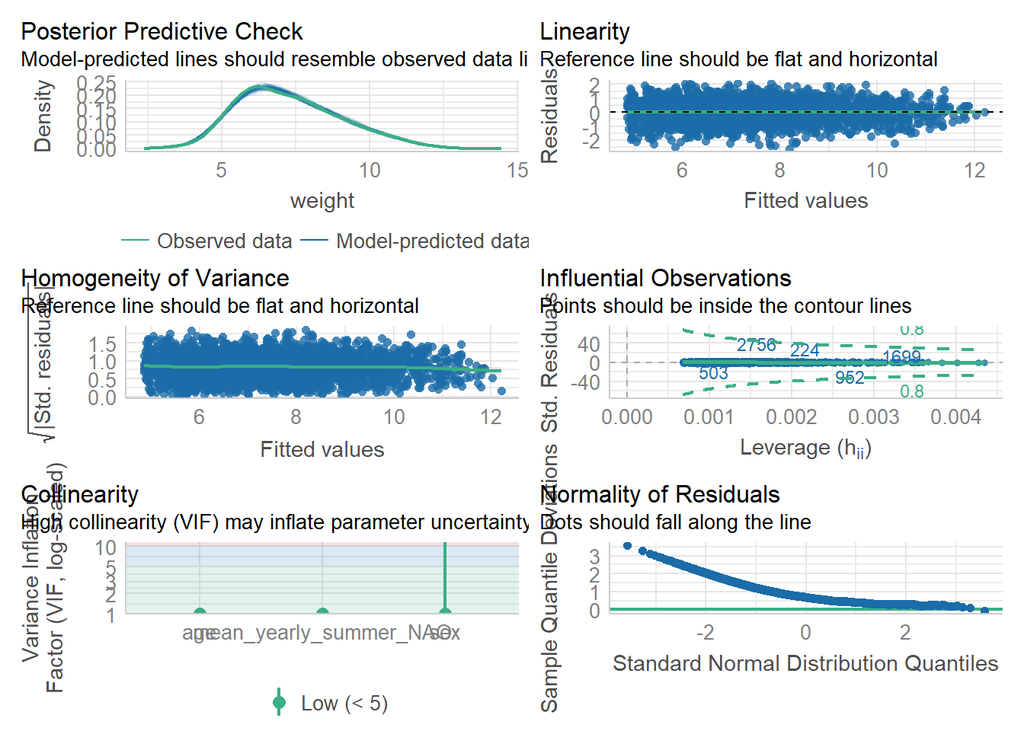

```r
library(performance)

check_model(glm_model)
```

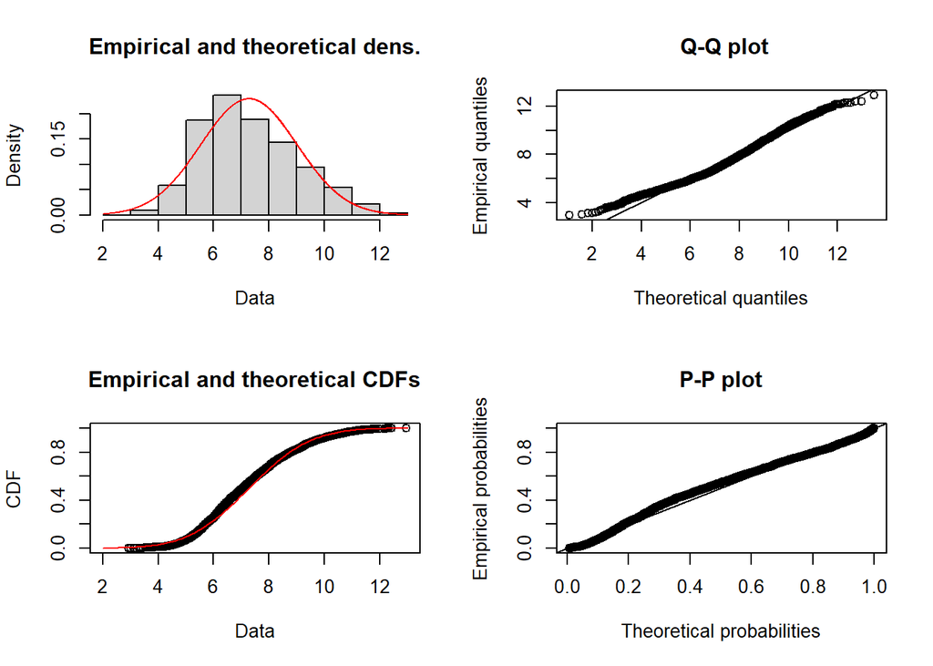

```r
fit <-fitdist(merged_data$weight, "norm")
plot(fit)
```

```r
gofstat(fit)
```

```
## Goodness-of-fit statistics
##                               1-mle-norm
## Kolmogorov-Smirnov statistic  0.06133973
## Cramer-von Mises statistic    2.90255165
## Anderson-Darling statistic   17.64975394
##
## Goodness-of-fit criteria
##                                1-mle-norm
## Akaike's Information Criterion   11069.54
## Bayesian Information Criterion   11081.41
```

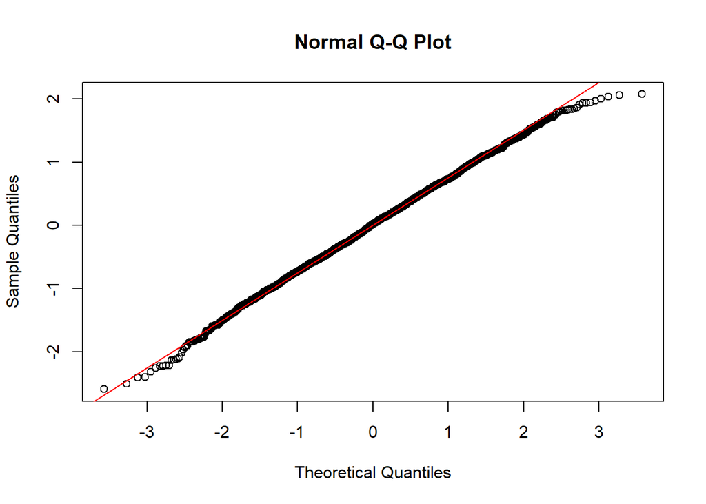

```r
qqnorm(residuals(glm_model)) #qq residual plot of my glm model
qqline(residuals(glm_model), col = "red") #qqlineplot to check the residuals are evenly distributed
```

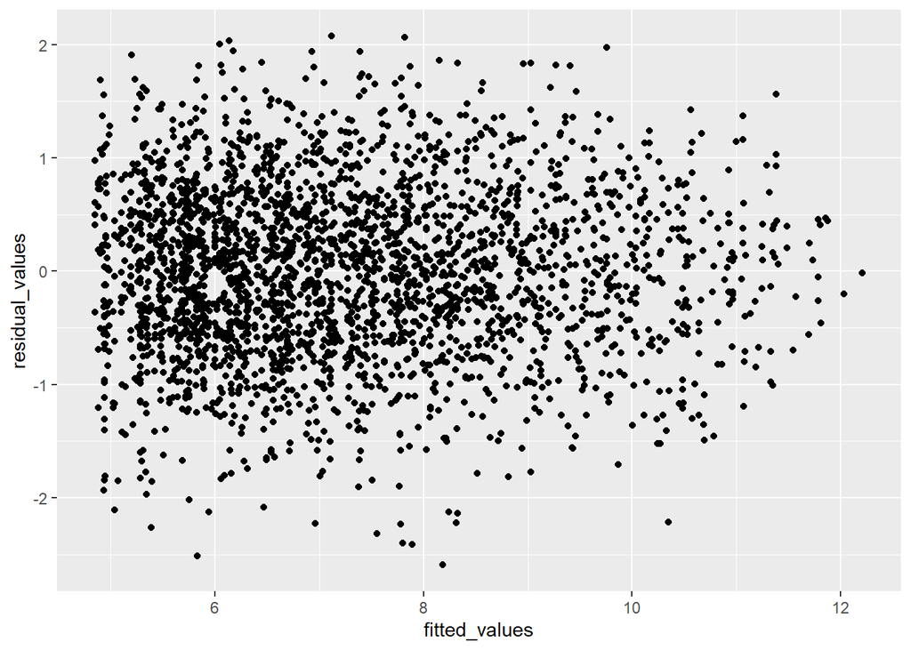

```r
fitted_values <- fitted(glm_model)
residual_values <- residuals(glm_model)
fitted_v_residual_data <- data.frame(fitted_values, residual_values)#vreating a dataframe for plotting

ggplot(data = fitted_v_residual_data, aes(y = residual_values, x= fitted_values)) +
  geom_point() +
  geom_abline(intercept = 0, slope = 1, col = "red") #ggplot showing the fitted vs residual values - checking for patterns indicating non linear data
```

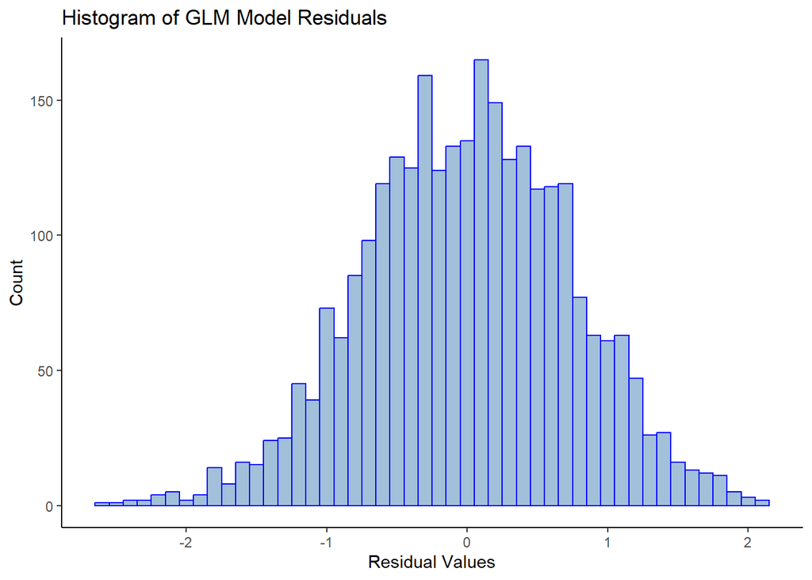

```r
ggplot(data = fitted_v_residual_data, aes(x = residual_values)) +
  geom_histogram(binwidth = 0.1, fill = "steelblue", col = "blue", alpha = 0.5) +
  theme_classic() +#histogram of model residuals, normal residuals produce a bell shape
  labs(title = "Histogram of GLM Model Residuals", x = "Residual Values", y = "Count")
```

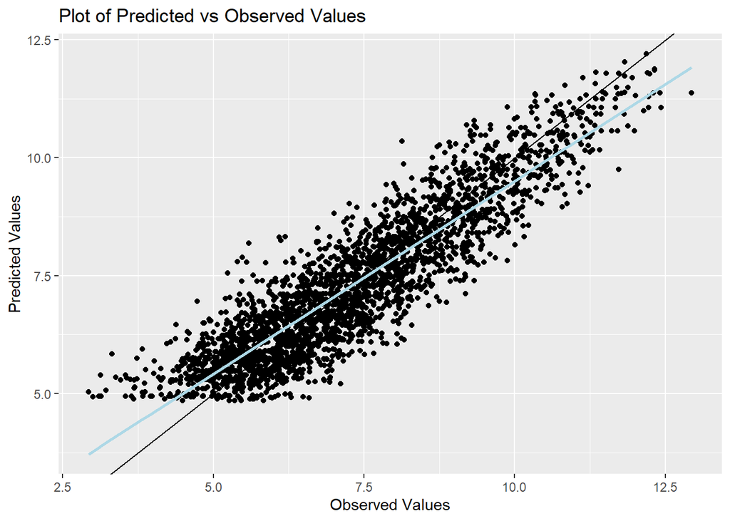

```r
##visualize the fitted vs observed values - this was done to indicate model fit of the glm and assess necessity of the glmm
fit_data <- data.frame("predicted"= glm_model$fitted.values,
                       "observed" = merged_data$weight)
##plot them
ggplot(fit_data, aes(x=observed, y=predicted)) +
  geom_point() +
  ##add a 1:1 line
  geom_abline(intercept = 0) +
  ##add a linear regression to your data
  geom_smooth(method="lm",
              col="lightblue",
              se = F)   +
  labs(title = "Plot of Predicted vs Observed Values ", x = "Observed Values", y = "Predicted Values")
```

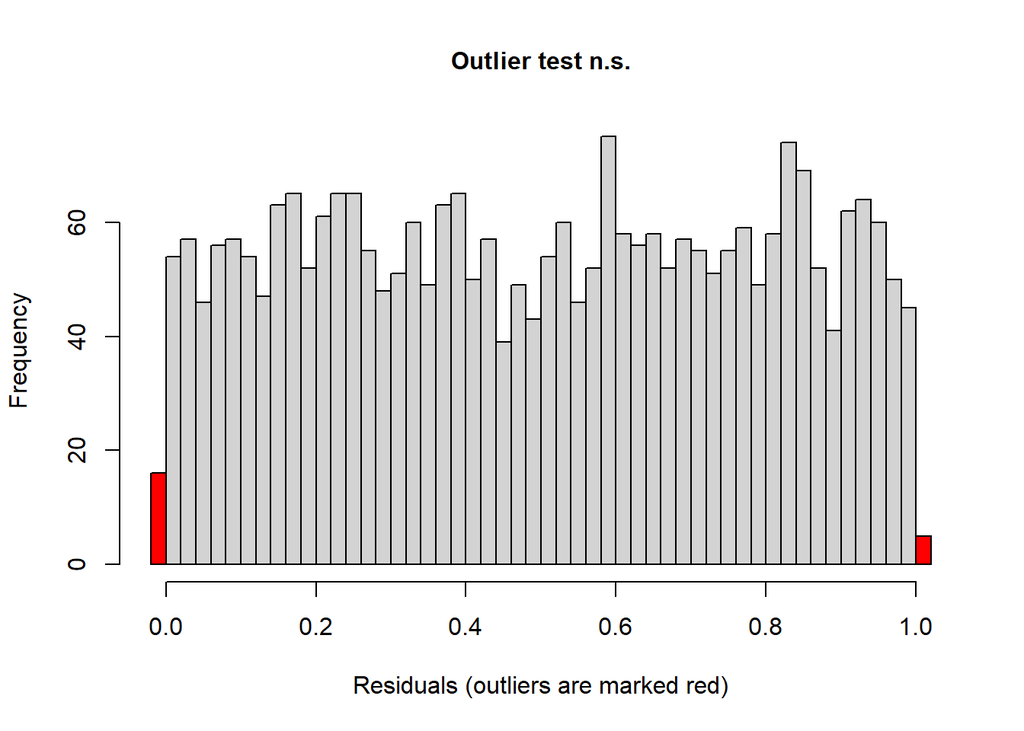

```
##
##  DHARMa outlier test based on exact binomial test with approximate
##  expectations
##
## data:  glm_model
## outliers at both margin(s) = 21, observations = 2804, p-value = 0.9152
## alternative hypothesis: true probability of success is not equal to 0.007968127
## 95 percent confidence interval:
##  0.004641799 0.011425521
## sample estimates:
## frequency of outliers (expected: 0.00796812749003984 )
##                                            0.007489301
```

```r
testOutliers(glm_model) #testing for outliers which deviate significantly to what is expected by the model
```

While the model indicates predominantly normal residuals/variance. However the fitted vs observed plot indicated unexplained variance. These are not explained by outliers so a glmm was appropriate.

# Fitting/Testing the GLMM

```r
library(lme4)
library(glmmTMB)
library(tidyr)
library(car)
library(MuMIn)


model_correct <- glmmTMB(weight ~ age + mean_yearly_summer_NAO + sex + (1|ID) + (1|pop_size), data = merged_data, family = gaussian())

summary(model_correct)
```

```
##  Family: gaussian  ( identity )
## Formula:
## weight ~ age + mean_yearly_summer_NAO + sex + (1 | ID) + (1 |      pop_size)
## Data: merged_data
##
##      AIC      BIC   logLik deviance df.resid
##   2975.1   3016.7  -1480.6   2961.1     2797
##
## Random effects:
##
## Conditional model:
##  Groups   Name        Variance Std.Dev.
##  ID       (Intercept) 0.40135  0.6335
##  pop_size (Intercept) 0.03687  0.1920
##  Residual             0.10553  0.3249
## Number of obs: 2804, groups:  ID, 395; pop_size, 23
##
## Dispersion estimate for gaussian family (sigma^2): 0.106
##
## Conditional model:
##                        Estimate Std. Error z value Pr(>|z|)
## (Intercept)            4.796486   0.070860   67.69  < 2e-16 ***
## age                    0.396276   0.002591  152.92  < 2e-16 ***
## mean_yearly_summer_NAO 0.512449   0.072172    7.10 1.24e-12 ***
## sexm                   0.538918   0.065813    8.19 2.64e-16 ***
## ---
## Signif. codes:  0 '***' 0.001 '**' 0.01 '*' 0.05 '.' 0.1 ' ' 1
```

```r
model_pop <- glmmTMB(weight ~ age + mean_yearly_summer_NAO + sex + mean_yearly_summer_NAO:pop_size + (1|ID) + (1|pop_size), data = merged_data, family = gaussian())



model_correct_residuals <- residuals(model_correct)
shapiro.test(model_correct_residuals) #shapiro test to check for normal distribution of the GLMM
```

```
##
##  Shapiro-Wilk normality test
##
## data:  model_correct_residuals
## W = 0.99937, p-value = 0.4816
```

```r
anova(model_correct, model_pop) #anova to test model suitability and fit
```

```
## Data: merged_data
## Models:
## model_correct: weight ~ age + mean_yearly_summer_NAO + sex + (1 | ID) + (1 | , zi=~0, disp=~1
## model_correct:     pop_size), zi=~0, disp=~1
## model_pop: weight ~ age + mean_yearly_summer_NAO + sex + mean_yearly_summer_NAO:pop_size + , zi=~0, disp=~1
## model_pop:     (1 | ID) + (1 | pop_size), zi=~0, disp=~1
##               Df    AIC    BIC  logLik deviance  Chisq Chi Df Pr(>Chisq)
## model_correct  7 2975.1 3016.7 -1480.6   2961.1
## model_pop      8 2976.7 3024.2 -1480.4   2960.7 0.4086      1     0.5227
```

```r
BIC(model_correct, model_pop) #A Bayesian Information Criterion between models
```

```
##               df      BIC
## model_correct  7 3016.716
## model_pop      8 3024.246
```

```r
AIC(model_correct, model_pop) #Akaike Information Criterion test between models
```

```
##               df      AIC
## model_correct  7 2975.144
## model_pop      8 2976.735
```

Shapiro test indicated normality, so gaussian family was appropriate. AIC, ANOVA and BIC indicate the model_correct is the best fit.

### R²c and R²m - Determining Model’s Explanatory Coverage

```r
library(MuMIn) #package for predicting R-squared values
r.squaredGLMM(model_correct) #performing an R test provided an idea as to the explanatory capcity of the model being tested
```

```
##            R2m       R2c
## [1,] 0.8153523 0.9641643
```

```r
r.squaredGLMM(model_pop) #due to similar AIC and BIC values, model was tested for increased explanatory power
```

```
##            R2m       R2c
## [1,] 0.8147066 0.9641628
```

The marginal R-squared value indicated that fixed effects account for 82% of the variance in weight. The conditional R-squared (variance explained by fixed and random effects) accounted for 96%. As the models explanatory coverage is similar, the model_correct is the simplest model which explains the predictors of weight, Ockham’s razor indicates it is the best option.

### Visual Diagnostic Checks

```r
residuals_summary <- summary(residuals(model_correct)) #checking for normal residual range centered around 0
print(residuals_summary)
```

```
##      Min.   1st Qu.    Median      Mean   3rd Qu.      Max.
## -1.239499 -0.200048 -0.004805  0.000000  0.206458  0.943335
```

```r
na_in_residuals <- any(is.na(residuals(model_correct))) #checking for NA values
print(na_in_residuals)
```

```
## [1] FALSE
```

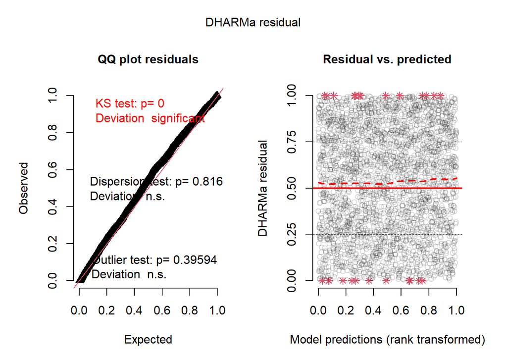

```r
library(ggpubr)
# Recreate the simulated residuals
simulation_output <- simulateResiduals(fittedModel = model_correct)

residuals_correct <- residuals(model_correct) #making residual data

# Plot the residuals
plot(simulation_output) # checking for homoscedasticity, normality, any patterns indicating model misfitting
```

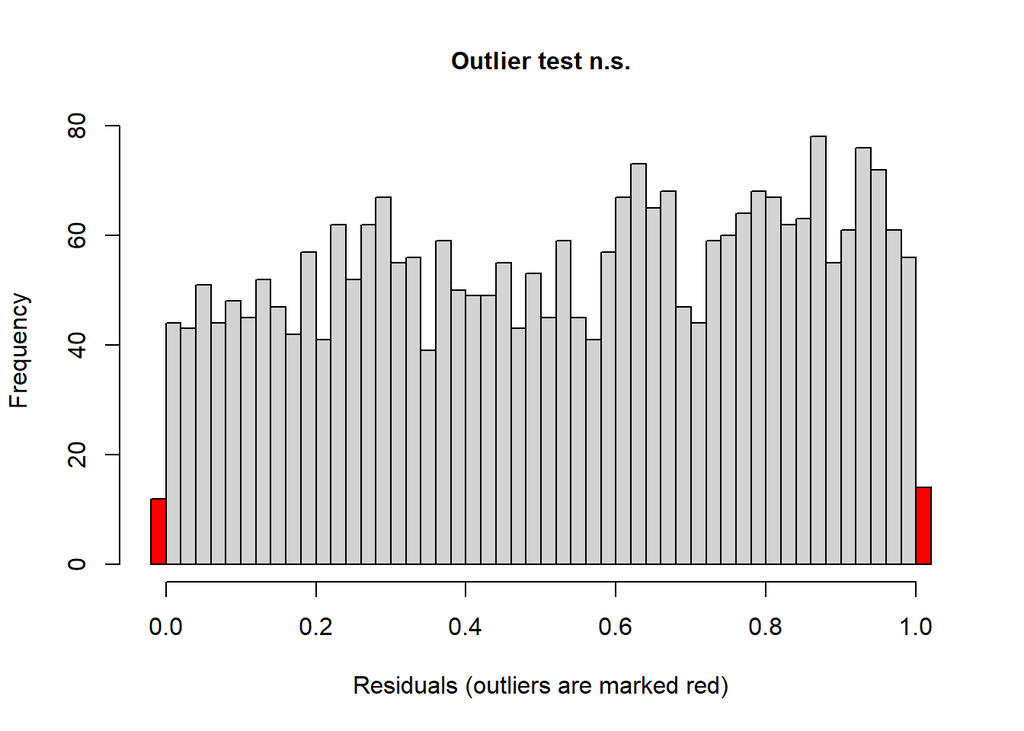

```
##
##  DHARMa outlier test based on exact binomial test with approximate
##  expectations
##
## data:  simulation_output
## outliers at both margin(s) = 26, observations = 2804, p-value = 0.3959
## alternative hypothesis: true probability of success is not equal to 0.007968127
## 95 percent confidence interval:
##  0.006065771 0.013556987
## sample estimates:
## frequency of outliers (expected: 0.00796812749003984 )
##                                            0.009272468
```

```r
testOutliers(simulation_output) # testing for significantly significant outliers
```

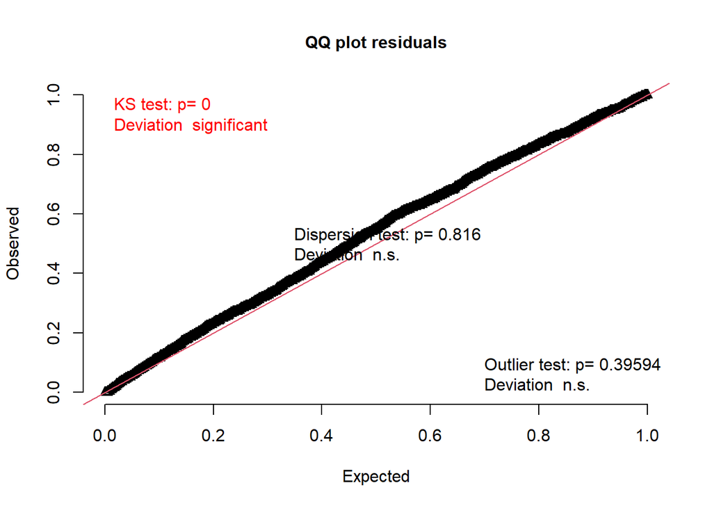

```
##
##  Asymptotic one-sample Kolmogorov-Smirnov test
##
## data:  simulationOutput$scaledResiduals
## D = 0.062756, p-value = 5.119e-10
## alternative hypothesis: two-sided
```

```r
testUniformity(simulation_output) #testing for uniform distribution of residuals
```

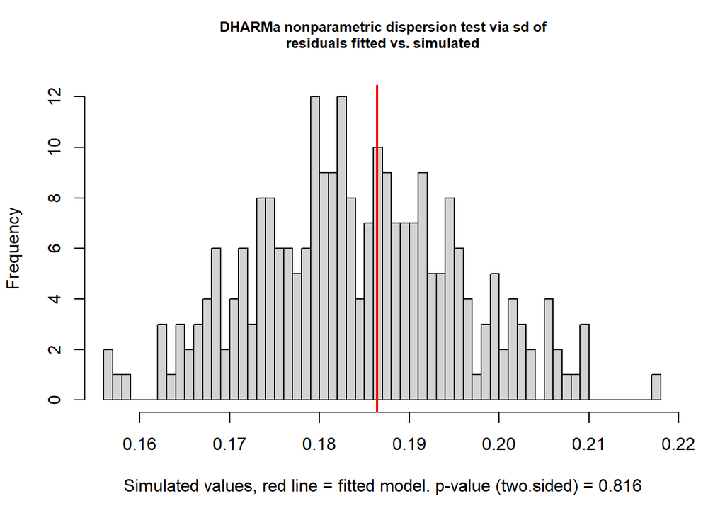

```
##
##  DHARMa nonparametric dispersion test via sd of residuals fitted vs.
##  simulated
##
## data:  simulationOutput
## dispersion = 1.0126, p-value = 0.816
## alternative hypothesis: two.sided
```

```r
testDispersion(simulation_output) #checking for over or underdispersion
```

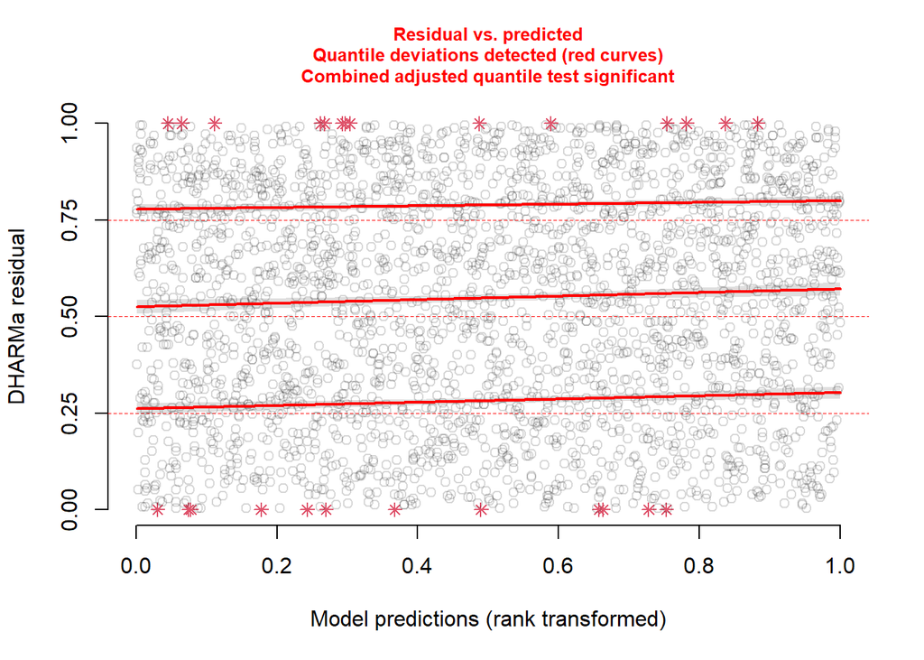

```
##
##  Test for location of quantiles via qgam
##
## data:  simulationOutput
## p-value = 2.027e-09
## alternative hypothesis: both
```

```r
testQuantiles(simulation_output) #checking observed quantiles meet expected quantiles
```

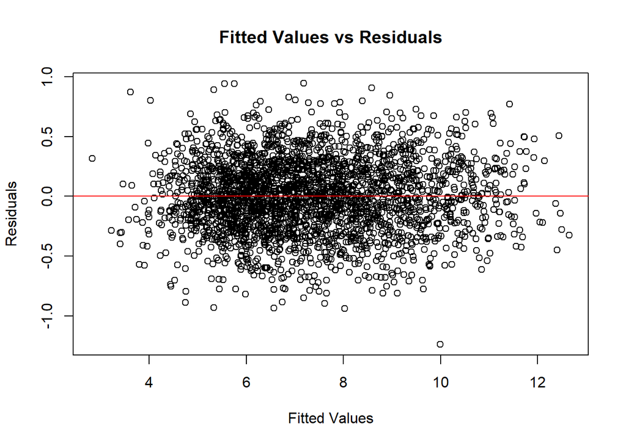

```r
plot(fitted(model_correct), residuals(model_correct), xlab = "Fitted Values", ylab = "Residuals", main = "Fitted Values vs Residuals")
abline(h = 0, col = "red") #redoing residual check directly from the model
```

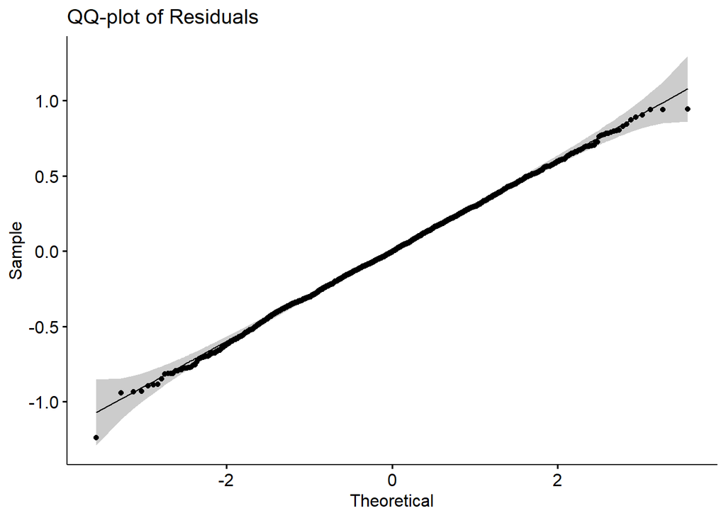

```r
ggqqplot(residuals_correct, main = "QQ-plot of Residuals") #qqplot of residuals, testing for normality
```

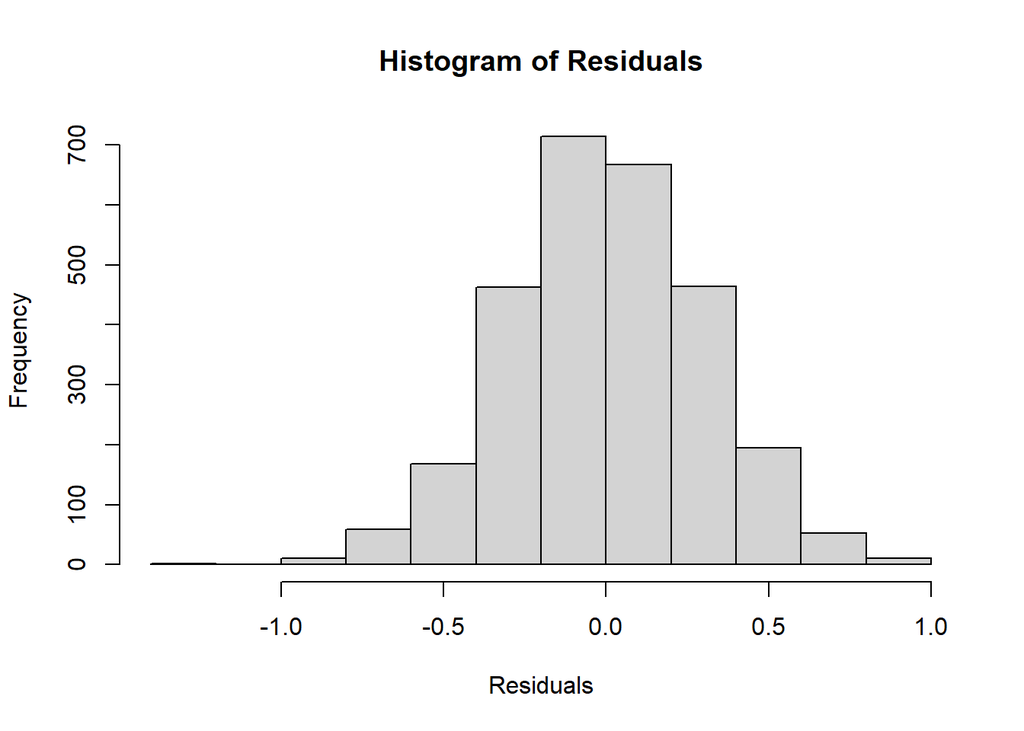

```r
hist(residuals(model_correct), main = "Histogram of Residuals", xlab = "Residuals")
```

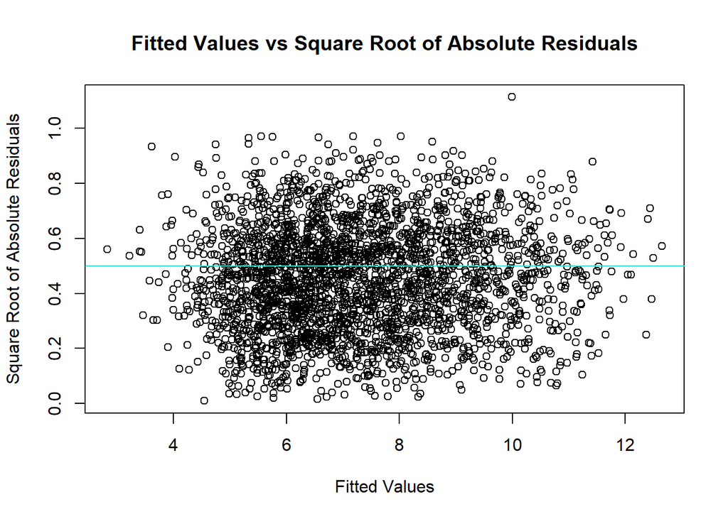

```r
plot(fitted(model_correct), sqrt(abs(residuals_correct)), main = "Fitted Values vs Square Root of Absolute Residuals", xlab = "Fitted Values", ylab = "Square Root of Absolute Residuals")
abline(h = 0.5, col = "turquoise")#square root of absolute residuals plotted to observe any patterns indicating poor data fit
```

Outlier test indicated no significant skewness. The dispersion of the model=1.01 and the p-value=0.8 indicated no significant over-dispersion. The residual quantiles were not where the model indicates they should be, however they were a close fit. The above plots indicate limited model bias, normal residual distribution and normality of variance. While the KS-test indicated the data does not model the expected distribution, other plots indicate normal distribution, so the model was taken forward regardless.

### Final Model Checks

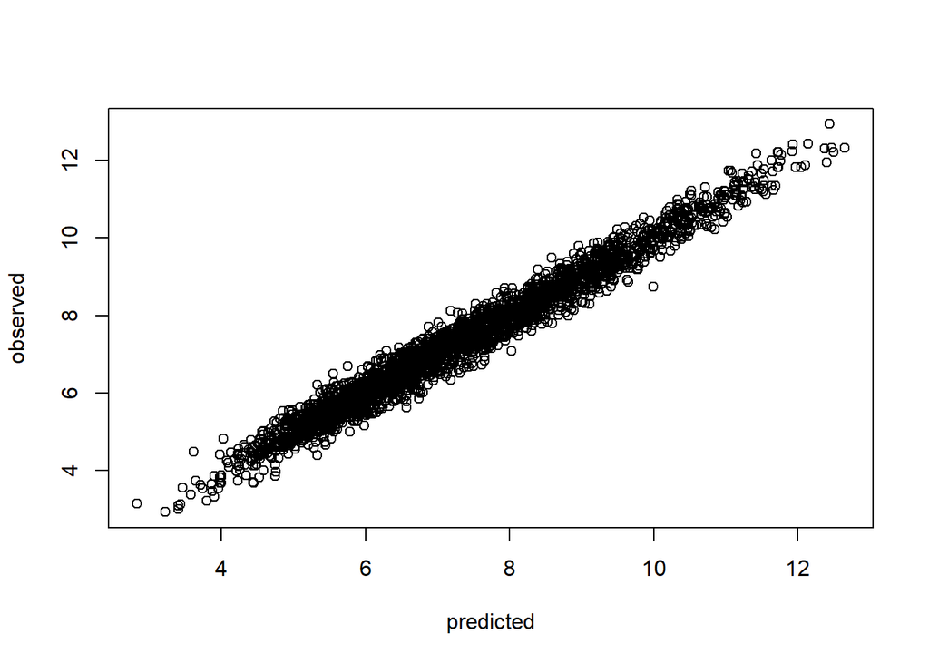

```r
p <- predict(model_correct, type = "response") #form the predicted dataset from the selected model

fit <- data.frame("predicted" = p, "observed" = merged_data$weight) #fit the predicted and observed values based on raw data

plot(fit) #initial plot of expected vs observed values
```

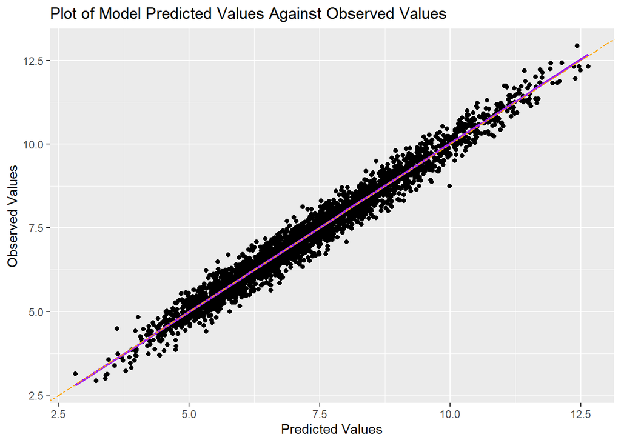

```r
ggplot(fit, aes(x = predicted, y = observed)) +
  geom_point() +
  geom_smooth(method = "lm", col = "purple") +
  geom_abline(intercept = 0, slope = 1, col = "orange", linetype = "twodash") +
  labs(x = "Predicted Values", y = "Observed Values", title = "Plot of Model Predicted Values Against Observed Values") #ggplot of the previous plot of observed vs predicted values - using a theoretical dotted orange line for where the predicted values are equal to observed
```

A ~1:1 relationship between predicted and observed weight indicates a robust predictive capacity for the GLMM to predict the effectors of weight in the Soay Sheep population. The interactions between weight, age, summer NAO and sex are effectively modelled as predictors and the random effects ID and population are appropriately accounted for.